# Statistical Methods

Hypotheses / NHST / p-values

Fall 2025 | Course PSYC 790  
Jeffrey M. Girard | Lecture 06a

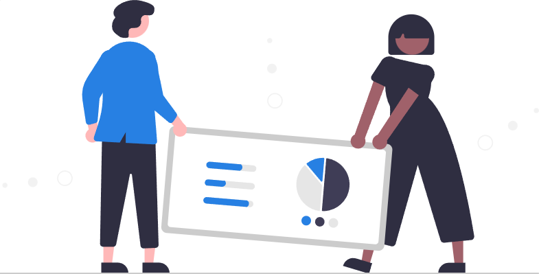

# Statistical Hypotheses

## What is a hypothesis?

- A hypothesis is a **testable** prediction
  - It derives from a broader scientific theory
  - It needs to be operationalized and falsifiable
- A statistical hypothesis needs to be mathematically **precise**
  - It is about characteristics of the population of interest
  - It is a *comparison* involving population parameters
    - The mean of the whole population is 100 $(\mu=100)$
    - The mean is greater in group 1 than group 2 $(\mu_1>\mu_2)$

## Example research question

- Imagine that we study *nutrition* and *obesity*
- Participants really like a brand of “low sugar” cereal
- The label claims that it only contains 3 g of sugar per serving
- However, we think this may be **false advertising**!
- We buy a *sample* of 20 cereal boxes from various stores
- We measure the amount of sugar per serving in each box
- **Is 3 g a reasonable estimate of the *population mean*?**

## Null and alternative hypotheses

- Just like in a criminal trial, we need to represent *both* sides
- The **null hypothesis** represents the company’s “defense”
  - Boxes *do* contain 3 g on average, or $H_0: \mu=3$
- The **alternative hypothesis** represents the “prosecution”
  - Boxes contain *more* than 3 g on average, or $H_1: \mu>3$
  - Boxes *do not* contain 3 g on average, or $H_2: \mu\neq3$

$H_1$ is a “one-sided” and $H_2$ is a “two-sided” hypothesis.

# NHST Logic

## What is NHST?

- In null hypothesis significance testing (NHST), the null hyp. is the defense and the alternative hyp. is the prosecution
- The statistical test is the *judge and jury* (makes the decision)
- We begin with a “presumption of innocence”
  - The null hypothesis is **assumed true** unless…
  - …there is good evidence that it is *very unlikely*
  - The burden of proof thus lies with the prosecution

NHST helps protect the null hypothesis from researchers who are incentivized to disprove it.

## Potential test outcomes

1. Retain the null hypothesis
   - There is not enough evidence to reject $\mu=3$
   - We cannot be certain that $\mu$ does not equal $3$
   - *It **does not** mean that we are certain that $\mu=3$*
2. Reject the null hypothesis
   - There is enough evidence to conclude $\mu\neq3$
   - The cereal’s nutrion label should be changed…
   - *It **does not** prove that this was deliberate fraud*

## Potential errors

- In reality, there is **only one correct decision**
  - In the two-sided case, either $\mu=3$ or $\mu\neq3$
- Due to *sampling error*, our sample may lead us astray
  - We might make one two possible wrong decisions…

|  | Retain $H_0$ | Reject $H_0$ |
| --- | --- | --- |
| $H_0$ **is True** | Correct Retain | Type I Error |
| $H_0$ **is False** | Type II Error | Correct Reject |

## Example outcomes

- In a world where the cereal *does* contain 3g on average
  - The **null hypothesis is true** and should be *retained*
  - If our test retains it, that is the correct decision
  - If our test rejects it, that is a Type I error
- In a world where the cereal *doesn’t* contain 3g on average
  - The **null hypothesis is false** and should be *rejected*
  - If our test retains it, that is a Type II error
  - If our test rejects it, that is the correct decision

## Controlling error rates

- NHST is particularly interested in preventing Type I errors
  - Researchers want to reject the null, so NHST protects it
- We control the Type I error rate $(\alpha)$ by modifying the test
  - e.g., we set $\alpha=.05$ to allow only 5% type I error
- We control the Type II error rate $(\beta)$ via large samples
  - We refer to a test’s **statistical power** as $1-\beta$
  - e.g., we decide $n$ to get 80% power (only 20% type II error)

## Outcome probabilities

|  | Retain $H_0$ | Reject $H_0$ |
| --- | --- | --- |
| $H_0$ **is True** | $1-\alpha$ | $\text{[I] }\alpha$ |
| $H_0$ **is False** | $\text{[II] }\beta$ | $1-\beta$ |

- If we set $\alpha$ to .05, we are accepting…
  - Up to a 5% (1 in 20) chance of rejecting a true null hyp.
- If we use a sample with 80% power, we are accepting…
  - Up to a 20% (1 in 5) chance of retaining a false null hyp.

# NHST Nuts and Bolts

## Test statistics

- How do we decide to retain or reject the null hypothesis?
- We compare our sample data to our “null expectations”
  - *What would we expect to see if the null were true?*
  - If they **match**, we we **retain** the null hypothesis
  - If they **do not match**, we **reject** the null hypothesis
- We need a way to quantify the extent of this matching
  - The test statistic quantifies the *mismatch*

## Test statistics

- The population mean expected under the null $(\mu_0)$ is 3
  - Our null expectation is a sample mean $(\bar{x})$ close to this
- The extent of matching here is captured by the difference
  - We can use the difference $(\Delta)$ as a simple test statistic
    $$\Delta = \bar{x} - \mu_0 \qquad \Delta = \bar{x} - 3$$
  - If the null is true, then $\Delta$ should be very close to zero
  - We would reject the null if $\Delta$ is too far from zero

## Critical values

- How far from zero is too far? When do we reject the null?
- We look at the sampling distribution of $\Delta$ under the null
  - If we assume that the null hypothesis is true…
  - …what values would we see with repeated samples?
- We can use this to make our statistical decision
  - We reject $H_0$ if the test statistic is unlikely under the null
  - If greater than the critical value, we reject the null
  - The critical value controls the Type I error rate $(\alpha)$

## Single sample $z$-test

- To set $\alpha=.05$, we reject the null if the test statistic is outside the middle 95% of its null sampling distribution
- The math becomes easier if we standardize the test statistic by dividing it by its standard error

$$z_{\bar{x}} = \frac{\bar{x} - \mu_0}{\sigma / \sqrt{n}} \\
z_{\bar{x}} \sim \mathcal{N}(0, 1)$$

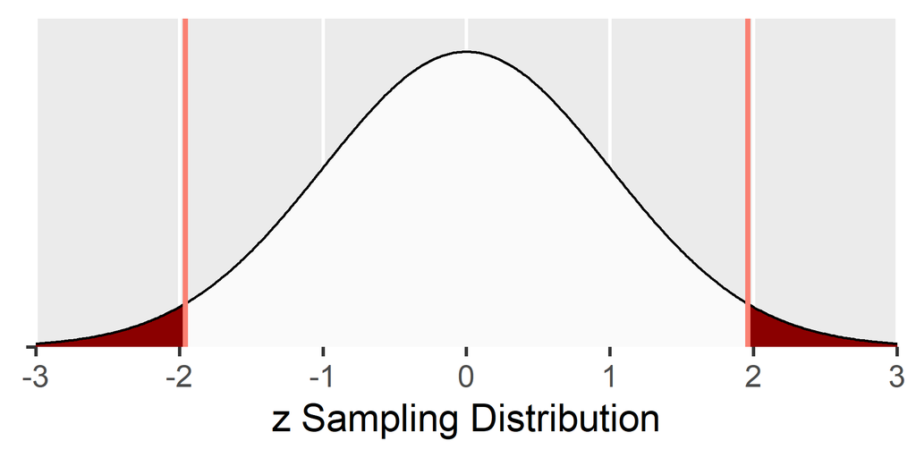

Critical values: $|z_{\bar{x}}| > 1.96$ (i.e., it falls in the red regions)

## Single sample $t$-test

- This $z$-test is rarely used because $\sigma$ is rarely known
- Instead, we estimate $\sigma$ using $s$ and use the $t$-test
- With a small sample, the critical values are now higher

$$t_{\bar{x}} = \frac{\bar{x} - \mu_0}{s / \sqrt{n}} \\
t_{\bar{x}} \sim t(n-1, 0, 1)$$

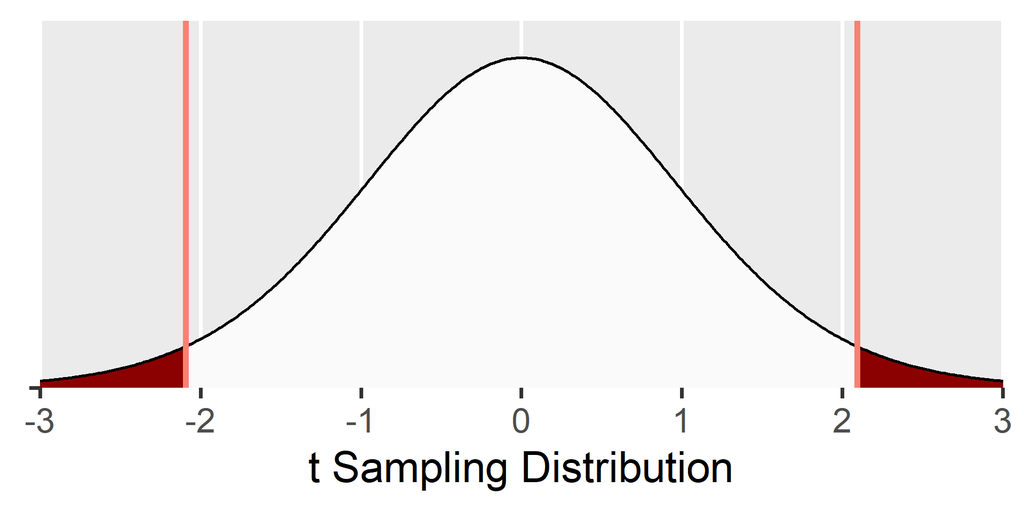

Critical values: $|t_{\bar{x}}| > 2.09$ (i.e., it falls in the red regions)

## Example where $H_0$ is true

Imagine $H_0$ is true $(\mu=3)$ and we collect the following sample of 20 cereal boxes

```r
sugar_null <- c(
  3.0, 3.1, 3.1, 3.1, 3.2,
  2.5, 3.1, 3.2, 3.0, 3.4,
  2.7, 2.9, 3.0, 3.4, 3.4,
  2.5, 3.4, 3.0, 3.4, 3.4
)
```

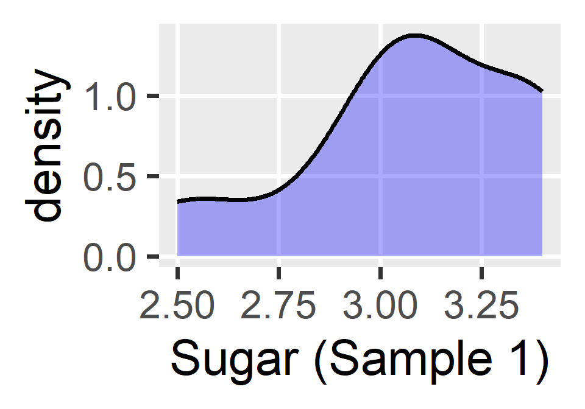

## Example where $H_0$ is true

```r
mu_0 <- 3
s <- sd(sugar_null)
se <- s / sqrt(n)
xbar <- mean(sugar_null)
xbar
## [1] 3.09

t_xbar <- (xbar - mu_0) / se
t_xbar
## [1] 1.423962

t_crit <- qt(0.975, df = n - 1)
t_crit
## [1] 2.093024
```

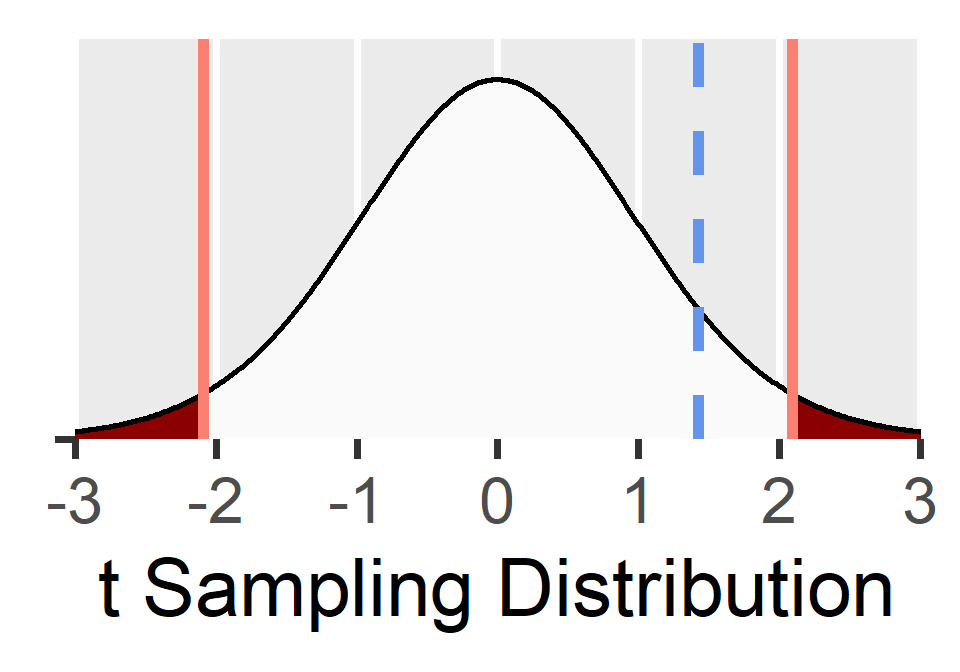

$|t_{\bar{x}}|<t_{crit}: \text{Retain }H_0$

## Example where $H_0$ is false

Imagine $H_0$ is false $(\mu=4)$ and we collect the following sample of 20 cereal boxes

```r
sugar_alt <- c(
  3.9, 3.0, 2.1, 3.8, 3.4,
  5.1, 3.1, 5.0, 3.6, 3.5,
  4.3, 3.6, 4.6, 4.7, 3.4,
  4.7, 4.6, 4.5, 4.9, 4.6
)
```

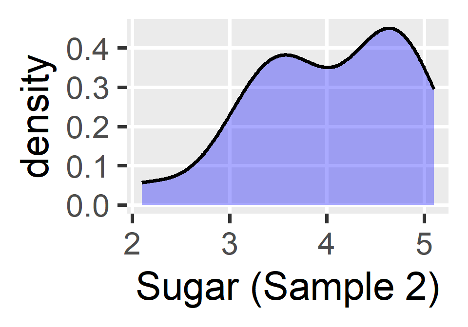

## Example where $H_0$ is false

```r
mu_0 <- 3
s <- sd(sugar_alt)
se <- s / sqrt(n)
xbar <- mean(sugar_alt)
xbar
## [1] 4.02

t_xbar <- (xbar - mu_0) / se
t_xbar
## [1] 5.699162

t_crit <- qt(0.975, df = n - 1)
t_crit
## [1] 2.093024
```

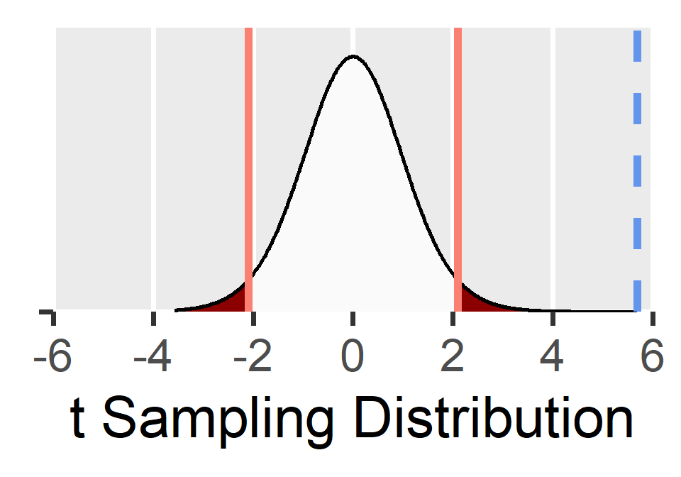

$|t_{\bar{x}}|>t_{crit}: \text{Reject }H_0$

## Making decisions

- Critical values let us decide and control $\alpha$
  - $t_{obs} < t_{crit}$ = Retain the null
  - $t_{obs} \ge t_{crit}$ = Reject the null
- When we reject the null, the test was “significant”
  - Remember that not all rejections are correct
  - Even a correct rejection may not be important
  - In a large sample, a small effect may be significant

# $p$-values and Pragmatics

## The $p$-value of a test

- But what if we had selected a different $\alpha$ level?
  - Some $\alpha$ values would yield a different decision
- The $p$-value is a popular approach for dealing with this

**Correct p-value Definitions**

The $p$-value is the smallest $\alpha$ value that would reject the null hypothesis.  
The $p$-value is the probability of observing a test statistic *at least* as extreme as ours.

**Wrong p-value Definition**

The $p$-value is the probability that the null hypothesis is true.

## Using the $p$-value

- The $p$-value is a summary of all possible $\alpha$ values
  - How would you feel about setting $\alpha$ to $p$?
- It is best to set $\alpha$ for the study *before* seeing the data
  - Then, you reject the null if and only if $p<\alpha$
- Reporting $p$ directly softens your decision
  - e.g., $p=.049$ (Reject) vs. $p=.051$ (Retain)
  - e.g., $p=.002$ (Reject) vs. $p=.047$ (Reject)

## Reporting a significance test

```r
tribble(
  ~Notation, ~Stars, ~Translation, ~Decision,
  "p ≥ .05", "", "Test was NOT significant at α=.05", "Retain Null",
  "p < .05", "*", "Test was significant at α=.05", "REJECT Null",
  "p < .01", "**", "Test was significant at α=.01", "REJECT Null",
  "p < .001", "***", "Test was significant at α=.001", "REJECT Null"
) |>
  knitr::kable() |>
  kableExtra::kable_styling(font_size = 32)
```

| Notation | Stars | Translation | Decision |
| --- | --- | --- | --- |
| p ≥ .05 |  | Test was NOT significant at α=.05 | Retain Null |
| p < .05 | * | Test was significant at α=.05 | REJECT Null |
| p < .01 | ** | Test was significant at α=.01 | REJECT Null |
| p < .001 | *** | Test was significant at α=.001 | REJECT Null |

- Report your exact $p$-value (unless less than .001)
  - Saying $p<.05$ or $p\ge.05$ discards useful information
- It can be helpful to report a CI and your test statistic too

## Putting it all together

- We can do a one-sample $t$-test in R with `t.test()`
- We can get a results table with `model_parameters()`

```r
fit1 <- t.test(sugar_null, mu = 3)

library(easystats)
model_parameters(fit1)
## One Sample t-test
##
## Parameter  | Mean | mu | Difference |       95% CI | t(19) |     p
## ------------------------------------------------------------------
## sugar_null | 3.09 |  3 |       0.09 | [2.96, 3.22] |  1.42 | 0.171
##
## Alternative hypothesis: true mean is not equal to 3
```

## Interpreting the results

```
One Sample t-test

Parameter  | Mean | mu | Difference |       95% CI | t(19) |     p
------------------------------------------------------------------
sugar_null | 3.09 |  3 |       0.09 | [2.96, 3.22] |  1.42 | 0.171

Alternative hypothesis: true mean is not equal to 3
```

> “The mean sugar content per serving in our sample was 3.09 g, 95% CI: [2.96, 3.22], which was not significantly different from the 3 g stated on the label, $t(19)=1.42$, $p=.171$. Thus, we retain the null hypothesis that there are 3 g of sugar per serving.”

## Putting it all together… again

- Let’s repeat with the other sample

```r
fit2 <- t.test(sugar_alt, mu = 3)

model_parameters(fit2)
## One Sample t-test
##
## Parameter | Mean | mu | Difference |       95% CI | t(19) |      p
## ------------------------------------------------------------------
## sugar_alt | 4.02 |  3 |       1.02 | [3.65, 4.39] |  5.70 | < .001
##
## Alternative hypothesis: true mean is not equal to 3
```

## Interpreting the results

```
One Sample t-test

Parameter | Mean | mu | Difference |       95% CI | t(19) |      p
------------------------------------------------------------------
sugar_alt | 4.02 |  3 |       1.02 | [3.65, 4.39] |  5.70 | < .001

Alternative hypothesis: true mean is not equal to 3
```

> “The mean sugar content per serving in our sample was 4.02 g, 95% CI: [3.65, 4.39], which was significantly greater than the 3 g stated on the label, $t(19)=5.70$, $p<.001$. Thus, we reject the null hypothesis that there are 3 g of sugar per serving.”